# talk slides

## data mountains

## turn your data into mountains!

### census 2021 data for england and wales is out now, we want to show the data on a map

#### we are interested in the part of england that has the the fastest growing population and the highest population density:

##### *The London Borough of Tower Hamlets*

### where is tower hamlets?

[figure not shown]

### we use choropleth maps a lot

#### but this one looks washed out...

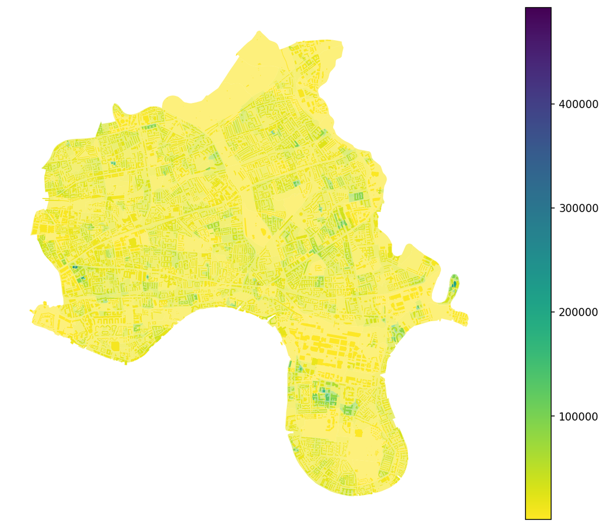

### ...oh yes, the data is not normally distributed

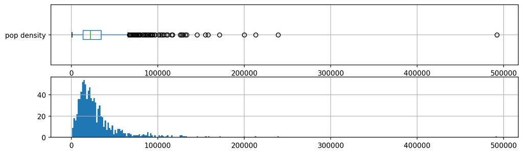

### so we log transform the data

#### ...but we lose the values in the legend

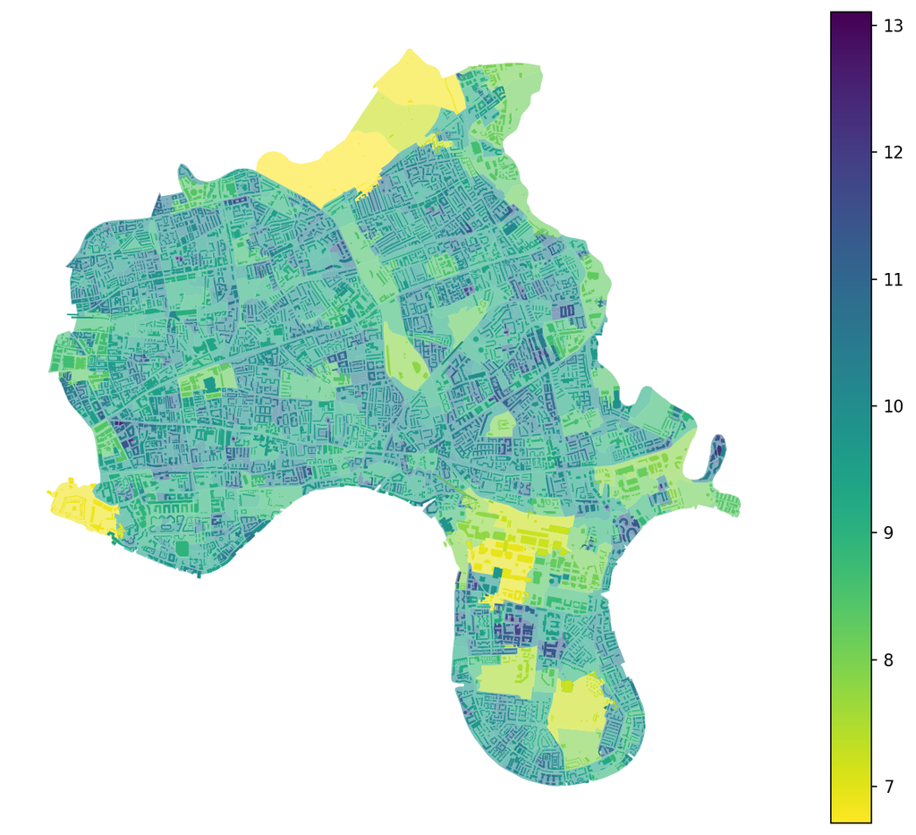

### let's try a density equalising cartogram

#### shout to the r cartogram package

#### nice, but harder to overlay on other data

[figure not shown]

### here's a neat visual from Datawrapper, cool!

### note: each of the census geographies polygons in this map contains 100-600 people, so density varies, *see the outlier at Limehouse?*

[figure not shown]

### ...remember this?

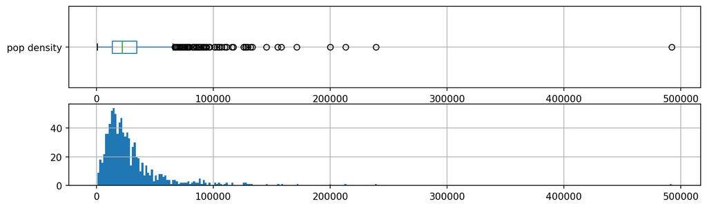

#### ...ah yes, that is a very small census area, so the density is high relative to the space

[figure not shown]

#### here it is, a statistical geography that is just one building

#### ... it happens - this is why the density is so high

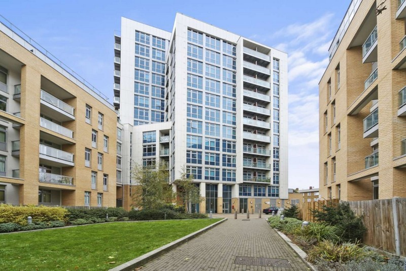

### playing with datawrapper was fun

#### the pointy map symbols reminded me of middle earth

[figure not shown]

### i tried to emulate hand drawn maps in python

#### the essence of data mountains is a simple function turns a point into a mountain, sized by a data attribute of that point

[figure not shown]

## population density

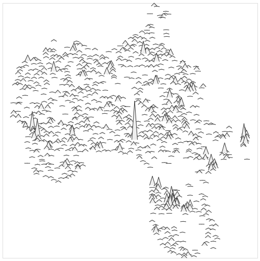

### population density is a bit odd at this spatial resolution

[figure not shown]

## let's try another dataset

### one bedroom homes

[figure not shown]

### two bedroom homes

[figure not shown]

### three bedroom homes

[figure not shown]

### four or more bedroom homes

[figure not shown]

### one more data mountains plot

#### westminster population density

[figure not shown]

### final words, this module was made with #nbdev!

#### using nbdev for this project made it extra fun, it helps you show good coder practice

1. it cleans cell metadata during version control, avoiding merge conflicts
2. it enables you to easily share:
   1. code
   2. docs
   3. tests
   4. modules ... all at once!

### also...

shout to jarek (sojourner.rocks), ed (wikidata osm link) and daniel stenberg (cURL)

### finally

shout to all the council workers around the world!